# EDA Tasks by Kaggle Project-5

Anjan Kumar Regulavalasa, Dominique Miranda, Tarun Gulati, Jenisha Rawal

2023-06-18

# Table of Contents

> Introduction to Business Problem.

> Task 1: Explore the target variable in application_{train|test}.csv. Is the data unbalanced with respect to the target?

> Task 2: Explore relationship between target and predictors, looking for potentially strong predictors that could be included later in a model.

> Task 3: Loading the skimr package and the janitor package for data exploration and data cleaning.

> Task 4: Exploration of Missing data Scope in train|test Data.

> Task 5: Checking for Columns with near-zero or zero variance and outliers.

> Task 6: Will the input data need to be transformed in order to be used in a model?

> Task 7: Joining application_train.csv with transactional data in, for example, bureau.csv or previous_application.csv.

> Task 8: Exploration of joined transactional data.

> Results: What does the data signify?

> Group Members Contribution.

> Introduction to Business Problem: A majority of the loan applications are rejected because of insufficient or non-existent credit histories of the applicant, who are forced to turn to untrustworthy lenders for their financial needs. To address this issue, Home Credit uses both Telco Data as well as Transactional Data, to predict the loan repayment abilities of the applicants. If an applicant is deemed fit and capable to repay a loan, his application is accepted or otherwise rejected.

#Task 1: Explore the target variable in application_{train|test}.csv. Is the data unbalanced with respect to the target?

```r
library(tidyverse)
```

```r
library(ggplot2)
library(caret)
library(e1071)
test <- read.csv(file = "application_test.csv", stringsAsFactors = TRUE)
train <- read.csv(file = "application_train.csv", stringsAsFactors = TRUE)

str(train)
```

```
## 'data.frame':    307511 obs. of  122 variables:
##  $ SK_ID_CURR                  : int  406901 411101 203629 241260 292353 435872 209911 421818 228945 175144 ...
##  $ TARGET                      : int  0 0 0 0 0 0 0 0 1 0 ...
##  $ NAME_CONTRACT_TYPE          : Factor w/ 2 levels "Cash loans","Revolving loans": 2 2 1 1 1 1 1 1 1 1 ...
##  $ CODE_GENDER                 : Factor w/ 3 levels "F","M","XNA": 1 1 1 1 2 1 2 2 1 2 ...
##  $ FLAG_OWN_CAR                : Factor w/ 2 levels "N","Y": 1 1 1 1 2 1 1 2 1 2 ...
##  $ FLAG_OWN_REALTY             : Factor w/ 2 levels "N","Y": 2 2 1 2 2 2 1 2 2 2 ...
##  $ CNT_CHILDREN                : int  0 0 0 0 0 0 0 0 0 0 ...
##  $ AMT_INCOME_TOTAL            : num  450000 675000 427500 427500 450000 ...
##  $ AMT_CREDIT                  : num  2250000 2250000 2205000 1842768 1704560 ...
##  $ AMT_ANNUITY                 : num  225000 225000 206168 177696 157869 ...
##  $ AMT_GOODS_PRICE             : num  2250000 2250000 2205000 1800000 1665000 ...
##  $ NAME_TYPE_SUITE             : Factor w/ 8 levels "","Children",..: 8 8 8 8 8 5 8 8 3 3 ...
##  $ NAME_INCOME_TYPE            : Factor w/ 8 levels "Businessman",..: 4 4 4 4 4 4 4 4 4 4 ...
##  $ NAME_EDUCATION_TYPE         : Factor w/ 5 levels "Academic degree",..: 2 2 5 2 5 2 2 2 5 3 ...
```

[output cut: 86 more lines]

```r
summary(train)
```

```
##    SK_ID_CURR         TARGET              NAME_CONTRACT_TYPE CODE_GENDER
##  Min.   :100002   Min.   :0.00000   Cash loans     :278232   F  :202448
##  1st Qu.:189146   1st Qu.:0.00000   Revolving loans: 29279   M  :105059
##  Median :278202   Median :0.00000                            XNA:     4
##  Mean   :278181   Mean   :0.08073
##  3rd Qu.:367143   3rd Qu.:0.00000
##  Max.   :456255   Max.   :1.00000
##
##  FLAG_OWN_CAR FLAG_OWN_REALTY  CNT_CHILDREN     AMT_INCOME_TOTAL
##  N:202924     N: 94199        Min.   : 0.0000   Min.   :    25650
##  Y:104587     Y:213312        1st Qu.: 0.0000   1st Qu.:   112500
##                               Median : 0.0000   Median :   147150
##                               Mean   : 0.4171   Mean   :   168798
##                               3rd Qu.: 1.0000   3rd Qu.:   202500
##                               Max.   :19.0000   Max.   :117000000
##
##    AMT_CREDIT       AMT_ANNUITY     AMT_GOODS_PRICE          NAME_TYPE_SUITE
##  Min.   :  45000   Min.   :  1616   Min.   :  40500   Unaccompanied  :248526
##  1st Qu.: 270000   1st Qu.: 16524   1st Qu.: 238500   Family         : 40149
##  Median : 513531   Median : 24903   Median : 450000   Spouse, partner: 11370
##  Mean   : 599026   Mean   : 27109   Mean   : 538396   Children       :  3267
##  3rd Qu.: 808650   3rd Qu.: 34596   3rd Qu.: 679500   Other_B        :  1770
##  Max.   :4050000   Max.   :258026   Max.   :4050000                  :  1292
##                    NA's   :12       NA's   :278       (Other)        :  1137
##              NAME_INCOME_TYPE                     NAME_EDUCATION_TYPE
##  Working             :158774   Academic degree              :   164
##  Commercial associate: 71617   Higher education             : 74863
##  Pensioner           : 55362   Incomplete higher            : 10277
##  State servant       : 21703   Lower secondary              :  3816
##  Unemployed          :    22   Secondary / secondary special:218391
##  Student             :    18
##  (Other)             :    15
##             NAME_FAMILY_STATUS           NAME_HOUSING_TYPE
##  Civil marriage      : 29775   Co-op apartment    :  1122
##  Married             :196432   House / apartment  :272868
##  Separated           : 19770   Municipal apartment: 11183
##  Single / not married: 45444   Office apartment   :  2617
##  Unknown             :     2   Rented apartment   :  4881
##  Widow               : 16088   With parents       : 14840
##
```

[output cut: 241 more lines]

```
##  Min.   :0.00               Min.   : 0.00             Min.   :  0.00
##  1st Qu.:0.00               1st Qu.: 0.00             1st Qu.:  0.00
##  Median :0.00               Median : 0.00             Median :  0.00
##  Mean   :0.03               Mean   : 0.27             Mean   :  0.27
##  3rd Qu.:0.00               3rd Qu.: 0.00             3rd Qu.:  0.00
##  Max.   :8.00               Max.   :27.00             Max.   :261.00
##  NA's   :41519              NA's   :41519             NA's   :41519
##  AMT_REQ_CREDIT_BUREAU_YEAR
##  Min.   : 0.0
##  1st Qu.: 0.0
##  Median : 1.0
##  Mean   : 1.9
##  3rd Qu.: 3.0
##  Max.   :25.0
##  NA's   :41519
```

```r
str(test)
```

```
## 'data.frame':    48744 obs. of  121 variables:
##  $ SK_ID_CURR                  : int  100001 100005 100013 100028 100038 100042 100057 100065 100066 100067 ...
##  $ NAME_CONTRACT_TYPE          : Factor w/ 2 levels "Cash loans","Revolving loans": 1 1 1 1 1 1 1 1 1 1 ...
##  $ CODE_GENDER                 : Factor w/ 2 levels "F","M": 1 2 2 1 2 1 2 2 1 1 ...
##  $ FLAG_OWN_CAR                : Factor w/ 2 levels "N","Y": 1 1 2 1 2 2 2 1 1 2 ...
##  $ FLAG_OWN_REALTY             : Factor w/ 2 levels "N","Y": 2 2 2 2 1 2 2 2 2 2 ...
##  $ CNT_CHILDREN                : int  0 0 0 2 1 0 2 0 0 1 ...
##  $ AMT_INCOME_TOTAL            : num  135000 99000 202500 315000 180000 ...
##  $ AMT_CREDIT                  : num  568800 222768 663264 1575000 625500 ...
##  $ AMT_ANNUITY                 : num  20561 17370 69777 49019 32067 ...
##  $ AMT_GOODS_PRICE             : num  450000 180000 630000 1575000 625500 ...
##  $ NAME_TYPE_SUITE             : Factor w/ 8 levels "","Children",..: 8 8 1 8 8 8 8 8 8 3 ...
##  $ NAME_INCOME_TYPE            : Factor w/ 7 levels "Businessman",..: 7 7 7 7 7 4 7 7 4 7 ...
##  $ NAME_EDUCATION_TYPE         : Factor w/ 5 levels "Academic degree",..: 2 5 2 5 5 5 2 2 2 2 ...
##  $ NAME_FAMILY_STATUS          : Factor w/ 5 levels "Civil marriage",..: 2 2 2 2 2 2 2 4 2 1 ...
```

[output cut: 86 more lines]

```r
summary(test)
```

```
##    SK_ID_CURR           NAME_CONTRACT_TYPE CODE_GENDER FLAG_OWN_CAR
##  Min.   :100001   Cash loans     :48305    F:32678     N:32311
##  1st Qu.:188558   Revolving loans:  439    M:16066     Y:16433
##  Median :277549
##  Mean   :277797
##  3rd Qu.:367556
##  Max.   :456250
##
##  FLAG_OWN_REALTY  CNT_CHILDREN     AMT_INCOME_TOTAL    AMT_CREDIT
##  N:15086         Min.   : 0.0000   Min.   :  26942   Min.   :  45000
##  Y:33658         1st Qu.: 0.0000   1st Qu.: 112500   1st Qu.: 260640
##                  Median : 0.0000   Median : 157500   Median : 450000
##                  Mean   : 0.3971   Mean   : 178432   Mean   : 516740
##                  3rd Qu.: 1.0000   3rd Qu.: 225000   3rd Qu.: 675000
##                  Max.   :20.0000   Max.   :4410000   Max.   :2245500
##
##   AMT_ANNUITY     AMT_GOODS_PRICE          NAME_TYPE_SUITE
##  Min.   :  2295   Min.   :  45000   Unaccompanied  :39727
##  1st Qu.: 17973   1st Qu.: 225000   Family         : 5881
##  Median : 26199   Median : 396000   Spouse, partner: 1448
##  Mean   : 29426   Mean   : 462619                  :  911
##  3rd Qu.: 37391   3rd Qu.: 630000   Children       :  408
##  Max.   :180576   Max.   :2245500   Other_B        :  211
##  NA's   :24                         (Other)        :  158
##              NAME_INCOME_TYPE                    NAME_EDUCATION_TYPE
##  Businessman         :    1   Academic degree              :   41
##  Commercial associate:11402   Higher education             :12516
##  Pensioner           : 9273   Incomplete higher            : 1724
##  State servant       : 3532   Lower secondary              :  475
##  Student             :    2   Secondary / secondary special:33988
##  Unemployed          :    1
##  Working             :24533
##             NAME_FAMILY_STATUS           NAME_HOUSING_TYPE
##  Civil marriage      : 4261    Co-op apartment    :  123
##  Married             :32283    House / apartment  :43645
##  Separated           : 2955    Municipal apartment: 1617
##  Single / not married: 7036    Office apartment   :  407
##  Widow               : 2209    Rented apartment   :  718
##                                With parents       : 2234
##
```

[output cut: 225 more lines]

```
##  Min.   :0.000             Min.   :0.000              Min.   :0.000
##  1st Qu.:0.000             1st Qu.:0.000              1st Qu.:0.000
##  Median :0.000             Median :0.000              Median :0.000
##  Mean   :0.002             Mean   :0.003              Mean   :0.009
##  3rd Qu.:0.000             3rd Qu.:0.000              3rd Qu.:0.000
##  Max.   :2.000             Max.   :2.000              Max.   :6.000
##  NA's   :6049              NA's   :6049               NA's   :6049
##  AMT_REQ_CREDIT_BUREAU_QRT AMT_REQ_CREDIT_BUREAU_YEAR
##  Min.   :0.000             Min.   : 0.000
##  1st Qu.:0.000             1st Qu.: 0.000
##  Median :0.000             Median : 2.000
##  Mean   :0.547             Mean   : 1.984
##  3rd Qu.:1.000             3rd Qu.: 3.000
##  Max.   :7.000             Max.   :17.000
##  NA's   :6049              NA's   :6049
```

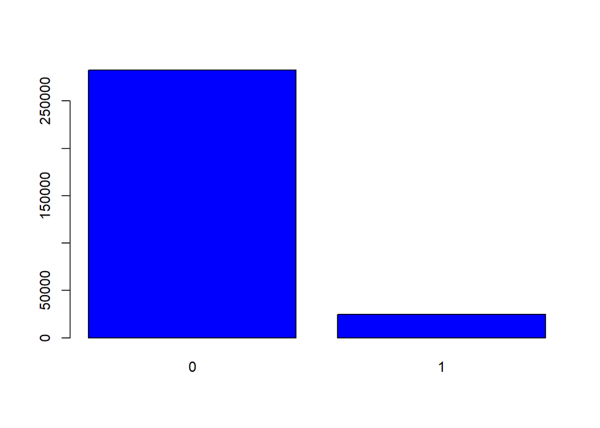

```r
barplot(table(train$TARGET),col="blue")
```

```r
prop.table(table(train$TARGET))
```

```
##
##          0          1
## 0.91927118 0.08072882
```

```r
simple_accuracy_reject <- train %>% summarize(credit_default = mean(TARGET == 0))
simple_accuracy_reject
```

```
##   credit_default
## 1      0.9192712
```

```r
simple_accuracy_accept <- train %>% summarize(credit_default = mean(TARGET == 1))
simple_accuracy_accept
```

```
##   credit_default
## 1     0.08072882
```

> Unbalanced because it is skewed, as (target==0) has a proportion of approximately 0.92, and (target==1) has a proportion of approximately 0.08. The accuracy of the model with the majority class classifier is 91.92%. With respect to the target, the data is unbalanced because it is skewed.

#Task 2: Explore relationship between target and predictors, looking for potentially strong predictors that could be included later in a model.

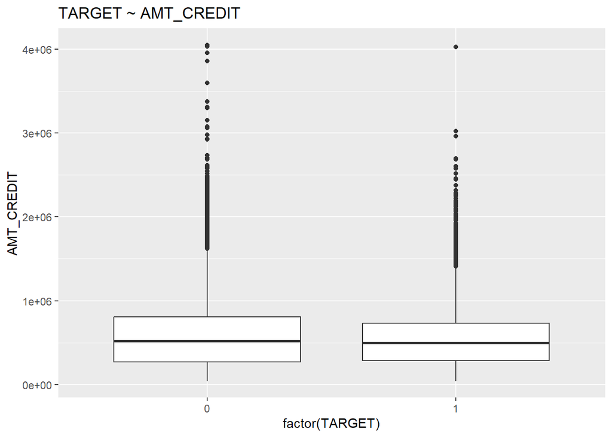

```r
ggplot(train, aes(x = factor(TARGET), y = AMT_CREDIT)) +
  geom_boxplot() +
  labs(title = "TARGET ~ AMT_CREDIT")
```

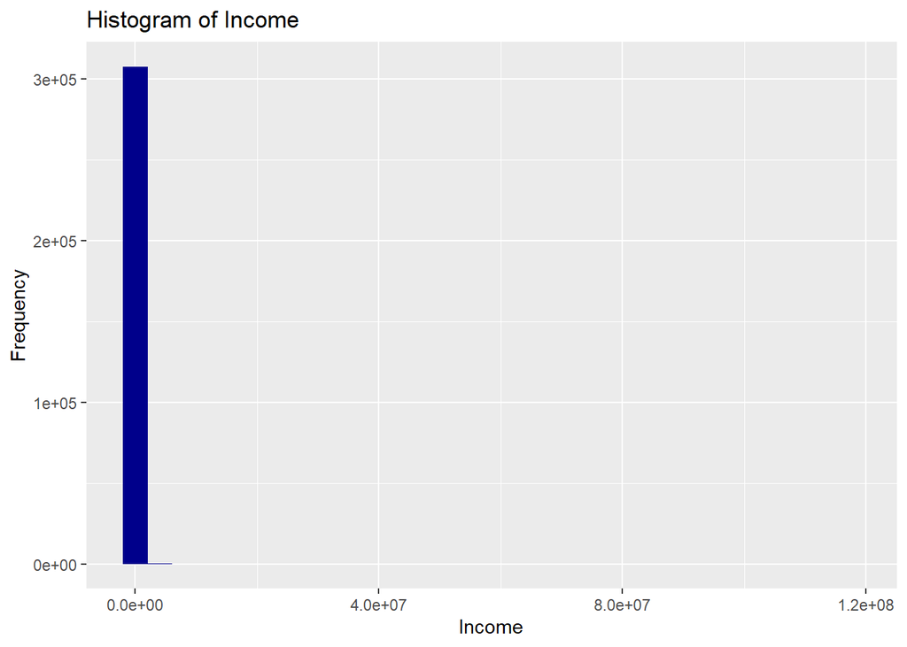

```r
ggplot(train,aes(x=AMT_INCOME_TOTAL))+
  geom_histogram(fill="darkblue") +
  xlab("Income") +
  ylab("Frequency") +
  ggtitle("Histogram of Income")
```

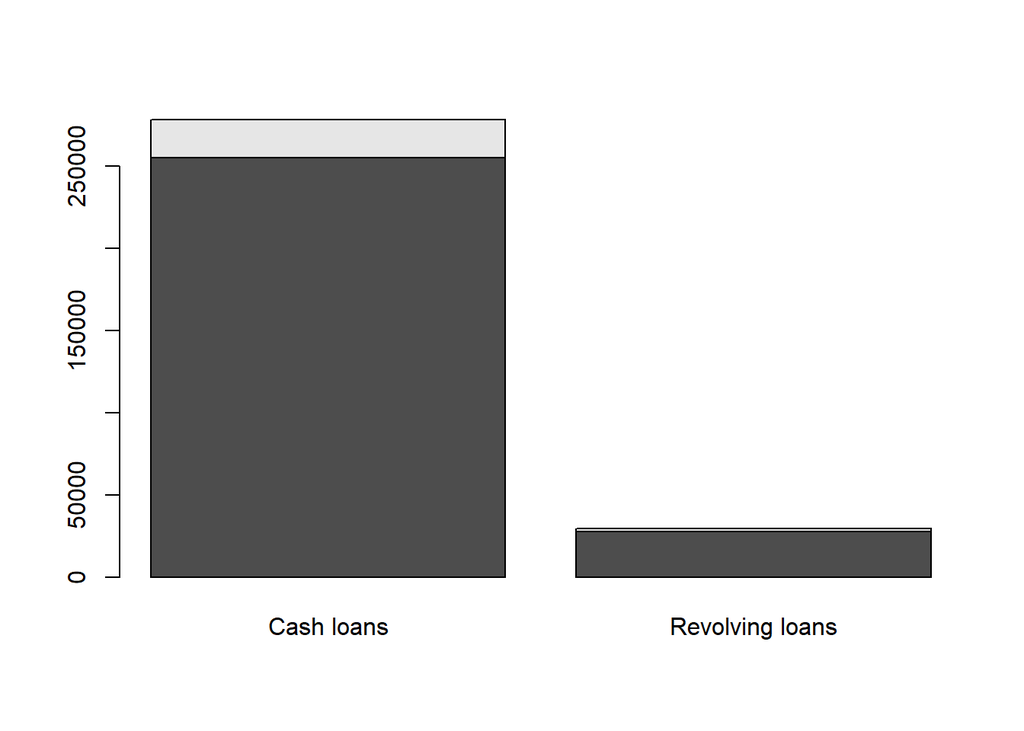

```r
barplot(table(train$TARGET, train$NAME_CONTRACT_TYPE))
```

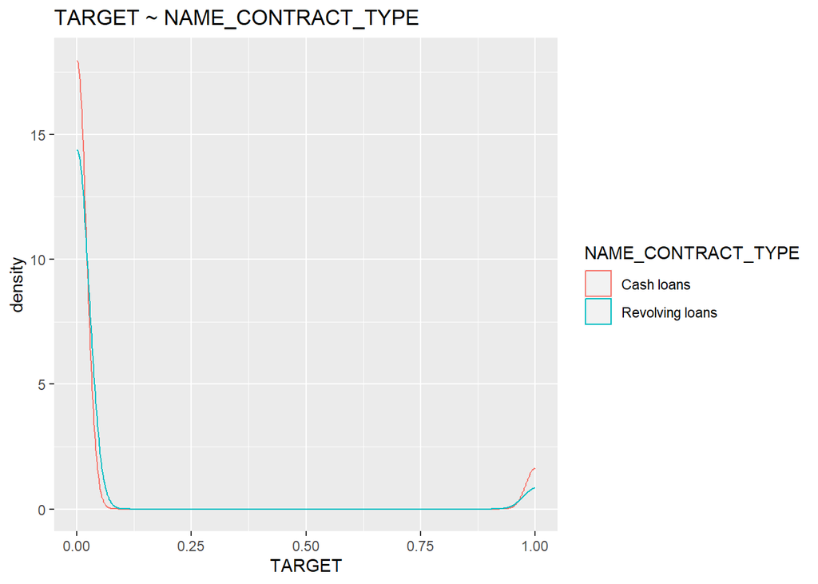

```r
ggplot(train, aes(x = TARGET, col = NAME_CONTRACT_TYPE)) + geom_density() + labs(title = "TARGET ~ NAME_CONTRACT_TYPE")
```

```r
#correlation
library(psych)
```

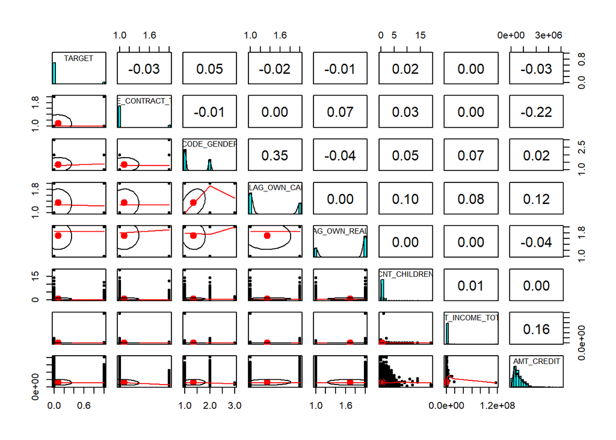

```r
# Specify the target variable and predictors
pairs.panels(train[2:9])
```

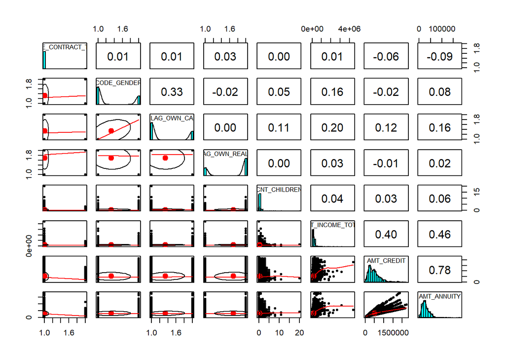

```r
pairs.panels(test[2:9])
```

# Task-3 Loading the skimr package and the janitor package for data exploration and data cleaning.

```r
# install.packages("skimr")
library(skimr)
# install.packages("janitor")
library(janitor)
# install.packages("readr")
library(readr)

summary <- skim(train)
print(summary)
```

```
## ── Data Summary ────────────────────────
##                            Values
## Name                       train
## Number of rows             307511
## Number of columns          122
## _______________________
## Column type frequency:
##   factor                   16
##   numeric                  106
## ________________________
## Group variables            None
##
## ── Variable type: factor ───────────────────────────────────────────────────────
##    skim_variable              n_missing complete_rate ordered n_unique
##  1 NAME_CONTRACT_TYPE                 0             1 FALSE          2
```

[output cut: 248 more lines]

# Task-4 Exploration of Missing data Scope in train|test Data.

```r
# Explore missing data wihtin the training dataset

train_missing_data <- skimr::skim(train)
train_missing_data <- arrange(train_missing_data, desc(n_missing))
print(train_missing_data)
```

```
## ── Data Summary ────────────────────────
##                            Values
## Name                       train
## Number of rows             307511
## Number of columns          122
## _______________________
## Column type frequency:
##   factor                   16
##   numeric                  106
## ________________________
## Group variables            None
##
## ── Variable type: factor ───────────────────────────────────────────────────────
##    skim_variable              n_missing complete_rate ordered n_unique
##  1 NAME_CONTRACT_TYPE                 0             1 FALSE          2
```

[output cut: 248 more lines]

```r
# Explore missing data within the testing dataset

test_missing_data <- skimr::skim(test)
test_missing_data <- arrange(test_missing_data, desc(n_missing))
print(test_missing_data)
```

```
## ── Data Summary ────────────────────────
##                            Values
## Name                       test
## Number of rows             48744
## Number of columns          121
## _______________________
## Column type frequency:
##   factor                   16
##   numeric                  105
## ________________________
## Group variables            None
##
## ── Variable type: factor ───────────────────────────────────────────────────────
##    skim_variable              n_missing complete_rate ordered n_unique
##  1 NAME_CONTRACT_TYPE                 0             1 FALSE          2
```

[output cut: 246 more lines]

```r
# Calculation of missing values percentage in each column within the training dataset

train_missing_percentages <- train_missing_data %>%
  janitor::tabyl(everything()) %>%
  janitor::adorn_percentages("col")

# Calculation of missing values percentage in each column within the testing dataset

test_missing_percentages <- test_missing_data %>%
  janitor::tabyl(everything()) %>%
  janitor::adorn_percentages("col")

# Print columns with missing data and their percentages for training data
print(train_missing_percentages)
```

```
##  skim_type         n   percent
##     factor 0.1311475 0.1311475
##    numeric 0.8688525 0.8688525
```

```r
# Print columns with missing data and their percentages for test data
print(test_missing_percentages)
```

```
##  skim_type         n   percent
##     factor 0.1322314 0.1322314
##    numeric 0.8677686 0.8677686
```

```r
# Impute missing values with 0 in the 'OWN_CAR_AGE' column
train <- train %>%
  replace_na(list(OWN_CAR_AGE = 0))
View(train)
print(head(train))
```

```
##   SK_ID_CURR TARGET NAME_CONTRACT_TYPE CODE_GENDER FLAG_OWN_CAR FLAG_OWN_REALTY
## 1     406901      0    Revolving loans           F            N               Y
## 2     411101      0    Revolving loans           F            N               Y
## 3     203629      0         Cash loans           F            N               N
## 4     241260      0         Cash loans           F            N               Y
## 5     292353      0         Cash loans           M            Y               Y
## 6     435872      0         Cash loans           F            N               Y
##   CNT_CHILDREN AMT_INCOME_TOTAL AMT_CREDIT AMT_ANNUITY AMT_GOODS_PRICE
## 1            0           450000    2250000    225000.0         2250000
## 2            0           675000    2250000    225000.0         2250000
## 3            0           427500    2205000    206167.5         2205000
## 4            0           427500    1842768    177696.0         1800000
## 5            0           450000    1704560    157869.0         1665000
## 6            0           270000    2330190    150799.5         2250000
##   NAME_TYPE_SUITE NAME_INCOME_TYPE           NAME_EDUCATION_TYPE
```

[output cut: 216 more lines]

```r
# Removal of columns with high percentage of missing data in train dataset

na_counts <- apply(train, 2, function(x) sum(is.na(x)))
missing_percent <- na_counts / nrow(train)
cols_to_remove <- names(missing_percent[missing_percent > 0.5])
train_clean_data <- train[, !(names(train) %in% cols_to_remove)]
print(head(train_clean_data))
```

```
##   SK_ID_CURR TARGET NAME_CONTRACT_TYPE CODE_GENDER FLAG_OWN_CAR FLAG_OWN_REALTY
## 1     406901      0    Revolving loans           F            N               Y
## 2     411101      0    Revolving loans           F            N               Y
## 3     203629      0         Cash loans           F            N               N
## 4     241260      0         Cash loans           F            N               Y
## 5     292353      0         Cash loans           M            Y               Y
## 6     435872      0         Cash loans           F            N               Y
##   CNT_CHILDREN AMT_INCOME_TOTAL AMT_CREDIT AMT_ANNUITY AMT_GOODS_PRICE
## 1            0           450000    2250000    225000.0         2250000
## 2            0           675000    2250000    225000.0         2250000
## 3            0           427500    2205000    206167.5         2205000
## 4            0           427500    1842768    177696.0         1800000
## 5            0           450000    1704560    157869.0         1665000
## 6            0           270000    2330190    150799.5         2250000
##   NAME_TYPE_SUITE NAME_INCOME_TYPE           NAME_EDUCATION_TYPE
```

[output cut: 153 more lines]

```r
# Extraction of the "OWN_CAR_AGE" column
OWN_CAR_AGE <- train_clean_data$OWN_CAR_AGE

# Defining the breaks and labels
breaks <- c(-Inf, 0, 5, 10, Inf)
labels <- c("0", "0-5", "5-10", "10+")

# Create bins
OWN_CAR_AGE_BINS <- cut(OWN_CAR_AGE, breaks = breaks, labels = labels)

# Append OWN_CAR_AGE_BINS to train dataset
train_clean_data <- cbind(train_clean_data, OWN_CAR_AGE_BINS)

#print(head(train_clean_data[, c("OWN_CAR_AGE_BINS", "OWN_CAR_AGE")], n=10))
```

> Here, columns that have more than 50% of missing values have been removed, expect ‘OWN_CAR_AGE’ column. The null values of this column has been replaced by ‘0’. Also, “OWN_CAR_AGE_BINS” column has been created for better interpretation of the “OWN_CAR_AGE” column. After cleaning and exploring the missing data, we have 307,511 rows and 86 columns.

# Task 5: Checking for Columns with near-zero or zero variance and outliers

```r
# Check for columns with near-zero variance
zero_var_cols <- names(train_clean_data)[apply(train_clean_data, 2, var) < 0.001]

# Output columns with near-zero variance
if (length(zero_var_cols) > 0) {
  cat("Columns with near-zero variance:", paste(zero_var_cols, collapse = ", "), "\n")
} else {
  cat("No columns with near-zero variance found.\n")
}
```

[output not shown]

```r
# Check for columns with zero variance
zero_var_cols <- names(train_clean_data)[apply(train_clean_data, 2, var) == 0]

# Output columns with zero variance
if (length(zero_var_cols) == 0) {
  cat("Columns with zero variance:", paste(zero_var_cols, collapse = ", "), "\n")
} else {
  cat("No columns with zero variance found.\n")
}
```

```
## No columns with zero variance found.
```

```r
# Calculation of the outliers for each column

set.seed(123)
threshold <- 3
num_outliers <- numeric()

for (col_name in colnames(train_clean_data)) {
  column <- train_clean_data[[col_name]]

  if (is.factor(column)) {
    num_outliers[col_name] <- sum(all(duplicated(column)[-1L]))
  } else {
    lower_bound <- mean(column) - threshold * sd(column)
    upper_bound <- mean(column) + threshold * sd(column)
    outliers <- column[column < lower_bound | column > upper_bound]
    num_outliers[col_name] <- length(outliers)
  }
}

for (col_name in names(num_outliers)) {
  cat("Column", col_name, ":", num_outliers[col_name], "outliers\n")
}
```

```
## Column SK_ID_CURR : 0 outliers
## Column TARGET : 24825 outliers
## Column NAME_CONTRACT_TYPE : 0 outliers
## Column CODE_GENDER : 0 outliers
## Column FLAG_OWN_CAR : 0 outliers
## Column FLAG_OWN_REALTY : 0 outliers
## Column CNT_CHILDREN : 4272 outliers
## Column AMT_INCOME_TOTAL : 454 outliers
## Column AMT_CREDIT : 3255 outliers
## Column AMT_ANNUITY : 307511 outliers
## Column AMT_GOODS_PRICE : 307511 outliers
## Column NAME_TYPE_SUITE : 0 outliers
## Column NAME_INCOME_TYPE : 0 outliers
## Column NAME_EDUCATION_TYPE : 0 outliers
## Column NAME_FAMILY_STATUS : 0 outliers
## Column NAME_HOUSING_TYPE : 0 outliers
## Column REGION_POPULATION_RELATIVE : 8412 outliers
## Column DAYS_BIRTH : 0 outliers
## Column DAYS_EMPLOYED : 0 outliers
## Column DAYS_REGISTRATION : 749 outliers
## Column DAYS_ID_PUBLISH : 0 outliers
## Column OWN_CAR_AGE : 4665 outliers
## Column FLAG_MOBIL : 1 outliers
## Column FLAG_EMP_PHONE : 0 outliers
## Column FLAG_WORK_PHONE : 0 outliers
## Column FLAG_CONT_MOBILE : 574 outliers
## Column FLAG_PHONE : 0 outliers
## Column FLAG_EMAIL : 17442 outliers
## Column OCCUPATION_TYPE : 0 outliers
## Column CNT_FAM_MEMBERS : 307511 outliers
## Column REGION_RATING_CLIENT : 0 outliers
## Column REGION_RATING_CLIENT_W_CITY : 0 outliers
## Column WEEKDAY_APPR_PROCESS_START : 0 outliers
## Column HOUR_APPR_PROCESS_START : 622 outliers
## Column REG_REGION_NOT_LIVE_REGION : 4657 outliers
## Column REG_REGION_NOT_WORK_REGION : 15612 outliers
## Column LIVE_REGION_NOT_WORK_REGION : 12503 outliers
## Column REG_CITY_NOT_LIVE_CITY : 24039 outliers
## Column REG_CITY_NOT_WORK_CITY : 0 outliers
## Column LIVE_CITY_NOT_WORK_CITY : 0 outliers
```

[output cut: 31 more lines]

```
## Column FLAG_DOCUMENT_14 : 903 outliers
## Column FLAG_DOCUMENT_15 : 372 outliers
## Column FLAG_DOCUMENT_16 : 3053 outliers
## Column FLAG_DOCUMENT_17 : 82 outliers
## Column FLAG_DOCUMENT_18 : 2500 outliers
## Column FLAG_DOCUMENT_19 : 183 outliers
## Column FLAG_DOCUMENT_20 : 156 outliers
## Column FLAG_DOCUMENT_21 : 103 outliers
## Column AMT_REQ_CREDIT_BUREAU_HOUR : 307511 outliers
## Column AMT_REQ_CREDIT_BUREAU_DAY : 307511 outliers
## Column AMT_REQ_CREDIT_BUREAU_WEEK : 307511 outliers
## Column AMT_REQ_CREDIT_BUREAU_MON : 307511 outliers
## Column AMT_REQ_CREDIT_BUREAU_QRT : 307511 outliers
## Column AMT_REQ_CREDIT_BUREAU_YEAR : 307511 outliers
## Column OWN_CAR_AGE_BINS : 0 outliers
```

# Task 6: Will the input data need to be transformed in order to be used in a model?

```r
train_cat_variables <- names(train_clean_data)[sapply(train_clean_data, is.factor)]

# Listing of the categorical variables
train_cat_variables
```

```
##  [1] "NAME_CONTRACT_TYPE"         "CODE_GENDER"
##  [3] "FLAG_OWN_CAR"               "FLAG_OWN_REALTY"
##  [5] "NAME_TYPE_SUITE"            "NAME_INCOME_TYPE"
##  [7] "NAME_EDUCATION_TYPE"        "NAME_FAMILY_STATUS"
##  [9] "NAME_HOUSING_TYPE"          "OCCUPATION_TYPE"
## [11] "WEEKDAY_APPR_PROCESS_START" "ORGANIZATION_TYPE"
## [13] "FONDKAPREMONT_MODE"         "HOUSETYPE_MODE"
## [15] "WALLSMATERIAL_MODE"         "EMERGENCYSTATE_MODE"
## [17] "OWN_CAR_AGE_BINS"
```

> Yes, the input data needs to be transformed inorder to used in a model. This involves preprocessing input data for model utilization which typically encompasses several essential tasks:

> 1.Handling missing values: This involves addressing the presence of missing data, which can entail imputing the missing values or removing rows or columns with incomplete information. The missing values of columns were addressed by replacing null values in “OWN_CAR_AGE” and by removal of columns with high percentage of missing values. 2.Encoding categorical variables: The dataset contains categorical variables which suggests to convert them into numerical format to ensure compatibility with the model. This process may involve techniques such as one-hot encoding and other appropriate methods. 3.Scaling or normalizing numeric variables: In certain situations, numeric variables may require scaling or normalization to bring them into a uniform range. This step ensures that the magnitudes of these variables do not disproportionately influence the model’s performance.

# Task 7: Joining application_train.csv with transactional data in, for example, bureau.csv or previous_application.csv.

```r
bureau <- read.csv("bureau.csv")

# Aggregate transactional data (bureau.csv) to have the same grain as application data
bureau_agg <- bureau %>%
  group_by(SK_ID_CURR) %>%
  summarise(
    bureau_count = n(),
    bureau_days_credit_mean = mean(DAYS_CREDIT),
    bureau_days_credit_min = min(DAYS_CREDIT),
    bureau_days_credit_max = max(DAYS_CREDIT)
  )

# Join aggregated transactional data (bureau.csv) with application data
train_bureau_agg <- left_join(train_clean_data, bureau_agg, by = "SK_ID_CURR")
print(head(train_bureau_agg))
```

```
##   SK_ID_CURR TARGET NAME_CONTRACT_TYPE CODE_GENDER FLAG_OWN_CAR FLAG_OWN_REALTY
## 1     406901      0    Revolving loans           F            N               Y
## 2     411101      0    Revolving loans           F            N               Y
## 3     203629      0         Cash loans           F            N               N
## 4     241260      0         Cash loans           F            N               Y
## 5     292353      0         Cash loans           M            Y               Y
## 6     435872      0         Cash loans           F            N               Y
##   CNT_CHILDREN AMT_INCOME_TOTAL AMT_CREDIT AMT_ANNUITY AMT_GOODS_PRICE
## 1            0           450000    2250000    225000.0         2250000
## 2            0           675000    2250000    225000.0         2250000
## 3            0           427500    2205000    206167.5         2205000
## 4            0           427500    1842768    177696.0         1800000
## 5            0           450000    1704560    157869.0         1665000
## 6            0           270000    2330190    150799.5         2250000
##   NAME_TYPE_SUITE NAME_INCOME_TYPE           NAME_EDUCATION_TYPE
```

[output cut: 167 more lines]

```r
previous_application <- read.csv("previous_application.csv")

# Aggregate transactional data (previous_application.csv) to have the same grain as application data
previous_agg <- previous_application %>%
  group_by(SK_ID_CURR) %>%
  summarise(
    prev_count = n(),
    prev_amt_credit_mean = mean(AMT_CREDIT),
    prev_amt_credit_min = min(AMT_CREDIT),
    prev_amt_credit_max = max(AMT_CREDIT)
  )

# Join aggregated transactional data (previous_application.csv) with application data
train_previous_agg <- left_join(train_clean_data, previous_agg, by = "SK_ID_CURR")
print(head(train_previous_agg))
```

```
##   SK_ID_CURR TARGET NAME_CONTRACT_TYPE CODE_GENDER FLAG_OWN_CAR FLAG_OWN_REALTY
## 1     406901      0    Revolving loans           F            N               Y
## 2     411101      0    Revolving loans           F            N               Y
## 3     203629      0         Cash loans           F            N               N
## 4     241260      0         Cash loans           F            N               Y
## 5     292353      0         Cash loans           M            Y               Y
## 6     435872      0         Cash loans           F            N               Y
##   CNT_CHILDREN AMT_INCOME_TOTAL AMT_CREDIT AMT_ANNUITY AMT_GOODS_PRICE
## 1            0           450000    2250000    225000.0         2250000
## 2            0           675000    2250000    225000.0         2250000
## 3            0           427500    2205000    206167.5         2205000
## 4            0           427500    1842768    177696.0         1800000
## 5            0           450000    1704560    157869.0         1665000
## 6            0           270000    2330190    150799.5         2250000
##   NAME_TYPE_SUITE NAME_INCOME_TYPE           NAME_EDUCATION_TYPE
```

[output cut: 160 more lines]

# Task 8:Exploration of joined transactional data

```r
# Exploration of the joined transactional data of bureau.
cor(train_bureau_agg[, c("TARGET", "bureau_days_credit_mean", "bureau_days_credit_min", "bureau_days_credit_max")])
```

```
##                         TARGET bureau_days_credit_mean bureau_days_credit_min
## TARGET                       1                      NA                     NA
## bureau_days_credit_mean     NA                       1                     NA
## bureau_days_credit_min      NA                      NA                      1
## bureau_days_credit_max      NA                      NA                     NA
##                         bureau_days_credit_max
## TARGET                                      NA
## bureau_days_credit_mean                     NA
## bureau_days_credit_min                      NA
## bureau_days_credit_max                       1
```

```r
# Analyzing the missing values and outliers
summary(train_bureau_agg[, c("bureau_days_credit_mean", "bureau_days_credit_min", "bureau_days_credit_max")])
```

```
##  bureau_days_credit_mean bureau_days_credit_min bureau_days_credit_max
##  Min.   :-2922.0         Min.   :-2922          Min.   :-2922.0
##  1st Qu.:-1456.8         1st Qu.:-2527          1st Qu.: -761.0
##  Median :-1049.0         Median :-1693          Median : -350.0
##  Mean   :-1097.5         Mean   :-1687          Mean   : -579.3
##  3rd Qu.: -650.5         3rd Qu.: -950          3rd Qu.: -162.0
##  Max.   :    0.0         Max.   :    0          Max.   :    0.0
##  NA's   :118833          NA's   :118833         NA's   :118833
```

```r
# Creation of new features
train_bureau_agg$bureau_credit_ratio <- train_bureau_agg$bureau_days_credit_mean / train_bureau_agg$AMT_CREDIT
```

```r
# Exploration of the joined transactional data of previous_applications.
cor(train_previous_agg[, c("TARGET", "prev_amt_credit_mean", "prev_amt_credit_min", "prev_amt_credit_max")])
```

```
##                      TARGET prev_amt_credit_mean prev_amt_credit_min
## TARGET                    1                   NA                  NA
## prev_amt_credit_mean     NA                    1                  NA
## prev_amt_credit_min      NA                   NA                   1
## prev_amt_credit_max      NA                   NA                  NA
##                      prev_amt_credit_max
## TARGET                                NA
## prev_amt_credit_mean                  NA
## prev_amt_credit_min                   NA
## prev_amt_credit_max                    1
```

```r
# Analyzing the missing values and outliers
summary(train_previous_agg[, c("prev_amt_credit_mean", "prev_amt_credit_min", "prev_amt_credit_max")])
```

```
##  prev_amt_credit_mean prev_amt_credit_min prev_amt_credit_max
##  Min.   :      0      Min.   :      0     Min.   :      0
##  1st Qu.:  66849      1st Qu.:      0     1st Qu.: 104432
##  Median : 117450      Median :  23805     Median : 225000
##  Mean   : 170070      Mean   :  48691     Mean   : 413866
##  3rd Qu.: 216072      3rd Qu.:  58905     3rd Qu.: 547344
##  Max.   :4050000      Max.   :4050000     Max.   :4509688
##  NA's   :16455        NA's   :16455       NA's   :16455
```

```r
# Creation of new features
train_previous_agg$prev_annuity_ratio <- train_previous_agg$AMT_ANNUITY / train_previous_agg$AMT_CREDIT
```

> Let’s explore the added columns and their potential for predicting default:

> By creating these new features, the code aims to capture additional information from the transactional data that could be relevant for predicting default in the application data. These features consider aspects such as credit duration, loan amount, annuity payment, and their ratios, which could provide valuable insights for modeling default risk.

# Results: What does the data signify?

> Data Preprocessing and Feature Selection: The dataset related to loan applications and loan repayment abilities undergoes data preprocessing and feature selection. Not all columns are included in the model, as some have high null values or insignificant contributions. Manipulation and transformation of certain columns are performed to ensure their correct impact on predictions.

> Addressing the Business Problem: The business problem at hand is the rejection of loan applications due to insufficient credit histories, leading applicants to seek loans from untrustworthy lenders. To tackle this issue, Home Credit utilizes Telco Data and Transactional Data to predict loan repayment abilities. This prediction aids in making informed decisions on accepting or rejecting loan applications.

> Unbalanced Data and Accuracy: The dataset is characterized as unbalanced since the target variable, which likely indicates loan repayment ability, is skewed. The majority class (target == 0) has a proportion of approximately 0.92, while the minority class (target == 1) has a proportion of approximately 0.08. This class imbalance impacts the model’s accuracy, with the majority class classifier achieving 91.92% accuracy.

> In summary, the provided information highlights the importance of data preprocessing and feature selection in a loan application dataset. It addresses the business problem of insufficient credit histories leading to loan rejections, utilizing Telco Data and Transactional Data for predicting loan repayment abilities. The unbalanced nature of the data and the accuracy of the majority class classifier are emphasized. Potential predictors and data exploration steps, including cleaning and the creation of additional columns, are also discussed, aimed at enhancing the model’s ability to predict loan repayment abilities and default risk.

# Group Members Contribution

> Dominique Miranda: Contributed to the Introduction, Task-1 and Task-2

> Anjan Kumar: Contributed to Task-3, Task-4, Results, Formatting

> Jenisha Rawal: Contributed to Task-5 and Task-6

> Tarun Gulati: Contributed to Task-7, Task-8, Proof-Reading